# Work Sample - Multilevel Modeling with the European Social Survey (2018)

2023-06-20

## R Markdown

This Markdown document is an additive to the application SOEP-17-23 Research Associate in which I want to demonstrate my ability to handle the ESS9 data set with multi-level analysis based on [Hox et. al. (2017)](https://www.taylorfrancis.com/books/mono/10.4324/9781315650982/multilevel-analysis-joop-hox-mirjam-moerbeek-rens-van-de-schoot).

This work sample is structured as follows:

1. Data Wrangling
2. Descriptive Analysis
3. Correlation Matrix
4. Hierarchical Modeling

# 1. Data Wrangling

#### 1.1 R-Packages

```r
library(haven)
library(lme4)
library(lmerTest)
library(performance)
library(vtable)
library(tidyverse)
library(stargazer)
library(ggplot2)
library(GGally)   # Distributions and Correlations
library(corrplot) # Correlation Heatmap
library(sjPlot)   # Visualisation for Multilevel - Models
library(datawizard)
library(texreg)
```

#### 1.2 Load Data

```r
knitr::opts_knit$set(root.dir = '~/Desktop/R-Projects//ESS9e03_1/')
ESS9 <- read_sav("ESS9e03_1.sav")

#ESS9 <- filter(ESS9, cntry %in% c("HU", "DE", "PT", "GB", "FI", "FR"))
```

#### 1.3 Data Wrangling

```r
MLA <- select(ESS9

              ,jstprev   # Confident that justice always prevails over injustice
                         # 1 Agree strongly - 5 Disagree strongly

              ,cptppola  # Confident in own ability to participate in politics
                         # 1 Not at all confident - 5 Completely confident

              ,lrscale   # Placement on left right scale
                         # 00 Left - 10 Right

              ,trstprl   # Trust in country's parliament
              ,trstlgl   # Trust in the legal system
                         # 00 No trust at all - 10 Complete trust

              ,grspfr    # Would you say your gross pay is unfairly low, fair, or unfairly high
                         # -4 Low, extremely unfair -  4 High, extremely unfair

              ,wltdffr   # Differences in wealth in country, how fair
                         # -4 Small, extremely unfair - 4 Large, extremely unfair

              ,evfredu   # Everyone in country fair chance achieve level of education they seek
              ,evfrjob   # Everyone in country fair chance get job they seek
                         # 00 Does not apply at all -1 0 Applies completely

              ,dscrgrp   # Member of a group discriminated against in this country
                         # 1 Yes - 2 No


              ,cntry)  %>%
  mutate(across(-cntry, as.numeric)) %>%
  mutate(cntry = as.factor(cntry))
```

# 2. Summary Statistics

```r
MLA %>%
  select(-cntry)%>%
  st(digits=2)
```

Summary Statistics

| Variable | N | Mean | Std. Dev. | Min | Pctl. 25 | Pctl. 75 | Max |
| --- | --- | --- | --- | --- | --- | --- | --- |
| jstprev | 48285 | 3.08 | 1.08 | 1 | 2 | 4 | 5 |
| cptppola | 48060 | 2.12 | 1.07 | 1 | 1 | 3 | 5 |
| lrscale | 42269 | 5.03 | 2.26 | 0 | 4 | 6 | 10 |
| trstprl | 48375 | 4.52 | 2.66 | 0 | 3 | 7 | 10 |
| trstlgl | 48511 | 5.33 | 2.75 | 0 | 3 | 8 | 10 |
| grspfr | 24955 | -1 | 1.4 | -4 | -2 | 0 | 4 |
| wltdffr | 46148 | 1.05 | 2.39 | -4 | 0 | 3 | 4 |
| evfredu | 48188 | 6.2 | 2.56 | 0 | 5 | 8 | 10 |
| evfrjob | 48236 | 4.86 | 2.49 | 0 | 3 | 7 | 10 |
| dscrgrp | 49076 | 1.92 | 0.26 | 1 | 2 | 2 | 2 |

```r
#st(MLA, group = "cntry")
```

# 3. Correlation Matrix

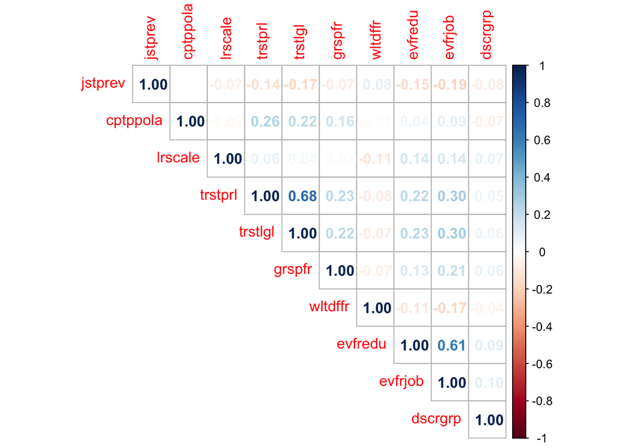

```r
mydata.cor <- MLA %>%
  select(-cntry) %>%
  cor(method = "spearman", use = "complete.obs")

corrplot(mydata.cor, method = "number", type = "upper",  cex.axis = 1.3)
```

# 4. Hierarchical Modeling

### 4.1 Intercept Only Model

```r
nullmodell <- lmer(jstprev ~ 1 + (1|cntry), data=ESS9, REML=F)
knitr::asis_output(htmlreg(nullmodell))
```

Statistical models

|  | Model 1 |
| --- | --- |
| (Intercept) | 3.09*** |
|  | (0.04) |
| AIC | 142468.15 |
| BIC | 142494.50 |
| Log Likelihood | -71231.07 |
| Num. obs. | 48285 |
| Num. groups: cntry | 29 |
| Var: cntry (Intercept) | 0.05 |
| Var: Residual | 1.12 |

***p < 0.001; **p < 0.01; *p < 0.05

The displayed model estimates the intercept of the item “Confident that justice always prevails over injustice” on a scale from “1 Agree strongly” to “5”Disagree strongly”.

### 4.1.1 ICC

```r
icc(nullmodell)
```

```
## # Intraclass Correlation Coefficient
##
##     Adjusted ICC: 0.039
##   Unadjusted ICC: 0.039
```

The Intraclass Correlation Coefficient is with 0.04 rather low. It indicates that 4% of the variance can be explained by country differences.

### 4.1.2 Visualisation of the Country Coefficients

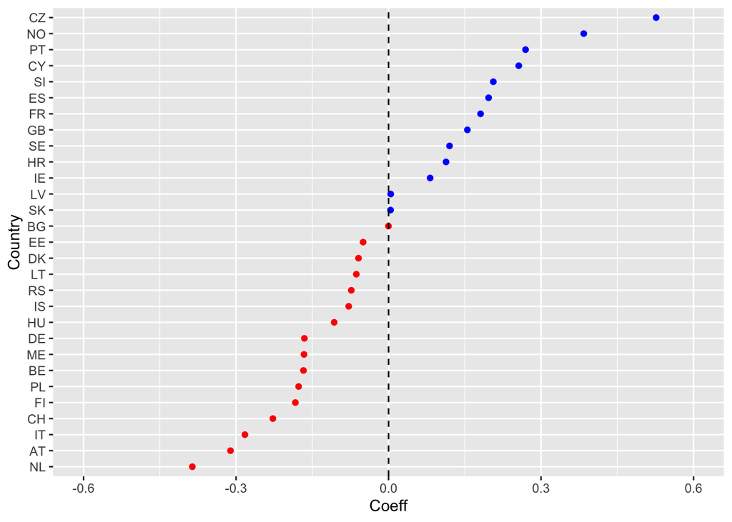

```r
random_effects <- ranef(nullmodell)
random_effects_df <- as.data.frame(random_effects)
ggplot(random_effects_df, aes(y = grp, x = condval, color = condval > 0)) +
  geom_point() +
  geom_vline(xintercept = 0, linetype = "dashed", color = "black") +
  scale_color_manual(values = c("red", "blue")) +
  labs(y = "Country", x = "Coeff") +
  xlim(c(-0.6, 0.6)) +
  guides(color = F)
```

The following graph illustrates the effects of the null model on different countries. When evaluating injustice, citizens in the Czech Republic, Norway, and Portugal have the least faith in justice, as indicated by their relatively high positive effects in the country comparison. Conversely, participants from the Netherlands, Austria, and Italy demonstrate the strongest negative effects in the model, suggesting a stronger belief in justice.

# 4.2 Fixed Slopes (Random intercept)

```r
MLA$dscrgrp <-  car::recode(MLA$dscrgrp, "1=1; 2=0") # Effect for member of a group discriminated

fixed_slopes <- lmer(jstprev~ 1 + dscrgrp + trstlgl+evfredu+(1|cntry), data=MLA, REML=F)

knitr::asis_output(htmlreg(fixed_slopes, custom.model.names = "Model 2"))
```

Statistical models

|  | Model 2 |
| --- | --- |
| (Intercept) | 3.75*** |
|  | (0.04) |
| dscrgrp | 0.18*** |
|  | (0.02) |
| trstlgl | -0.06*** |
|  | (0.00) |
| evfredu | -0.05*** |
|  | (0.00) |
| AIC | 134155.15 |
| BIC | 134207.60 |
| Log Likelihood | -67071.57 |
| Num. obs. | 46281 |
| Num. groups: cntry | 29 |
| Var: cntry (Intercept) | 0.05 |
| Var: Residual | 1.06 |

***p < 0.001; **p < 0.01; *p < 0.05

The second model includes the effects of belonging to a discriminated group (dscrgrp), having trust in the legal justice system (trstlgl), and believing that citizens have a fair chance to achieve the level of education they seek (evfredu). All independent variables are fixed in the model, and the deviance decreases compared to the null model. All the effects are statistically significant. Belonging to a discriminated group has a positive effect, while trust in legal institutions and belief in educational fairness have negative effects.

# 4.3.1 Random Slopes

```r
random_slopes <- lmer(jstprev ~ 1 + dscrgrp +trstlgl+evfredu + (1+dscrgrp|cntry),     data=MLA, REML=F)

knitr::asis_output(htmlreg(random_slopes, custom.model.names = "Model 3"))
```

Statistical models

|  | Model 3 |
| --- | --- |
| (Intercept) | 3.75*** |
|  | (0.04) |
| dscrgrp | 0.18*** |
|  | (0.02) |
| trstlgl | -0.06*** |
|  | (0.00) |
| evfredu | -0.05*** |
|  | (0.00) |
| AIC | 134157.10 |
| BIC | 134227.04 |
| Log Likelihood | -67070.55 |
| Num. obs. | 46281 |
| Num. groups: cntry | 29 |
| Var: cntry (Intercept) | 0.05 |
| Var: cntry dscrgrp | 0.00 |
| Cov: cntry (Intercept) dscrgrp | 0.00 |
| Var: Residual | 1.06 |

***p < 0.001; **p < 0.01; *p < 0.05

```r
coef(random_slopes)
```

```
## $cntry
##    (Intercept)    dscrgrp     trstlgl     evfredu
## AT    3.555834 0.21262224 -0.06452352 -0.05407335
## BE    3.576769 0.16534283 -0.06452352 -0.05407335
## BG    3.563190 0.12812006 -0.06452352 -0.05407335
## CH    3.643682 0.17582866 -0.06452352 -0.05407335
## CY    3.929937 0.21526547 -0.06452352 -0.05407335
## CZ    4.343047 0.18535470 -0.06452352 -0.05407335
## DE    3.650573 0.17605046 -0.06452352 -0.05407335
## DK    3.926310 0.16529806 -0.06452352 -0.05407335
## EE    3.813608 0.15566805 -0.06452352 -0.05407335
## ES    3.851038 0.18345170 -0.06452352 -0.05407335
## FI    3.717968 0.22052313 -0.06452352 -0.05407335
## FR    3.850269 0.15451601 -0.06452352 -0.05407335
## GB    3.904963 0.21354142 -0.06452352 -0.05407335
## HR    3.682556 0.14188849 -0.06452352 -0.05407335
## HU    3.620007 0.17050004 -0.06452352 -0.05407335
## IE    3.843572 0.24835423 -0.06452352 -0.05407335
## IS    3.754368 0.22125717 -0.06452352 -0.05407335
## IT    3.438325 0.16213635 -0.06452352 -0.05407335
## LT    3.650936 0.17222876 -0.06452352 -0.05407335
## LV    3.685889 0.13986569 -0.06452352 -0.05407335
## ME    3.497593 0.17440990 -0.06452352 -0.05407335
## NL    3.468545 0.19543587 -0.06452352 -0.05407335
## NO    4.354375 0.18614474 -0.06452352 -0.05407335
## PL    3.537331 0.19914785 -0.06452352 -0.05407335
## PT    3.895107 0.18733990 -0.06452352 -0.05407335
## RS    3.568784 0.09763952 -0.06452352 -0.05407335
## SE    3.980742 0.17953934 -0.06452352 -0.05407335
## SI    3.891549 0.17035994 -0.06452352 -0.05407335
## SK    3.679862 0.15952797 -0.06452352 -0.05407335
##
## attr(,"class")
## [1] "coef.mer"
```

The third model utilizes the same explanatory variables as model two, namely Discrimination, Trust, and Educational Fairness. In addition, this model incorporates random effects to account for belonging to a discriminated group within each country. To be seen are varying effect for discrimination on the evaluation of injustice.